# Item response theory example for marginal information criteria

January 10, 2018

## Latent regression Rasch model

Model for the response of person \(j\) to item (question) \(i\):

\[ \Pr(y_{ij} = 1 | \theta_j, \delta_i) = \mathrm{logit}^{-1} ( \theta_j - \delta_i ) \]

\[ \theta_j | \mathbf{x}_j', \boldsymbol{\lambda} \sim \mathrm{N}(\mathbf{x}_j' \boldsymbol{\lambda}, \psi^2) \]

- \(y_{ij} = 1\) if the response is correct, \(y_{ij} = 0\) otherwise
- \(\theta_j\) is the ability for person \(j\)
- \(\delta_i\) is the difficulty for item \(i\)
- \(\boldsymbol{\lambda}\) is a vector of regression coefficients
- \(\mathbf{x}_j\) is a vector of person-related variables

More on IRT and Stan: https://education-stan.github.io/

## Reparameterizing the model

Model may be parameterized in terms of residual \(\zeta_j\):

\[ \Pr(y_{ij} = 1 | \mathbf{x}_j, \boldsymbol{\lambda}, \delta_i, \zeta_j) = \mathrm{logit}^{-1} ( \mathbf{x}'_j \boldsymbol{\lambda} + \zeta_j - \delta_i ) \]

\[ \zeta_j \sim \mathrm{N}(0, \psi^2) \]

Non-hierarchical priors are:

\[ \lambda \sim t_3(0,1) \]

\[ \psi \sim \mathrm{exp(.1)} \]

\[ \delta_i \sim t_3(0,3) \]

## Conditional and marginal likelihoods

Conditional likelihood for \(y_{ij}\) at posterior draw \(s\):

\[ f_\text{c}(y_{ij} | \mathbf{x}_j, \boldsymbol{\lambda}^s, \delta_i^s, \zeta_j^s) = \Pr(y_{ij} | \mathbf{x}_j, \boldsymbol{\lambda}^s, \delta_i^s, \zeta_j^s) \]

Marginal likelihood for \(\mathbf{y}_j\) at posterior draw \(s\):

\[ f_\text{m}(\mathbf{y}_{j} | \mathbf{x}_j, \boldsymbol{\lambda}^s, \delta_i^s, \psi^s) = \int \prod_{i=1}^I f_\text{c}(y_{ij} | \mathbf{x}_j, \boldsymbol{\lambda}^s, \delta_i^s, \zeta_j) p(\zeta_j | \psi^s) ~ d\zeta_j \]

## Adaptive quadrature

Let \(\tilde \mu_j\) and \(\tilde \phi_j\) be the posterior mean and standard deviation for residual \(\zeta_j\)

Let \(a_{m}\) and \(w_m\) be the location and weight for standard quadrature node \(m\) (from `statmod` package, for example), for \(m = 1 \ldots M\)

Adaptive quadrature node locations and weights for cluster \(j\) are:

\[ a_{jm} = \tilde \mu_j + \tilde \phi_j \times a_m \]

\[ w_{jm}^s = \sqrt{2\pi} \times \tilde \phi_j \times \exp \left ( \frac{a_{jm}^2}{2} \right ) \times g \left ( a_{jm}; 0, \psi^{2,s} \right ) \times w_m \]

Marginal likelihood is then approximated as:

\[ f_\text{m}(\mathbf{y}_j | \mathbf{x}_j, \boldsymbol{\lambda}^s, \delta_i^s, \psi_j^s)\ \approx \ \sum_{m=1}^M w_{jm}^s \prod_{i=1}^I f_\text{c}(y_{ij} | \mathbf{x}_j, \boldsymbol{\lambda}^s, \delta_i^s, \zeta_j^s=a_{jm}) \]

An extension of Rabe-Hesketh, Skrondal, & Pickles (2005)

## Example dataset: Verbal agression (1/2)

24 items, for example:

- "A bus fails to stop for me. I would want to curse."
- "I miss a train because a clerk gave me faulty information. I would scold."
- "The grocery store closes just as I am about to enter. I would shout."

Responses are coded:

- 1 = "Perhaps" or "Yes"
- 0 = "No"

From Vansteelandt, K. (2000). Formal models for contextualized personality psychology. Unpublished doctoral dissertation. K. U. Leuven, Belgium.

## Example dataset: Verbal agression (2/2)

The data consists of:

- \(I = 24\) items
- \(J = 316\) persons
- Two person covariates (`anger`, `male`):
  1. `male`, whether the person is male (.5) or female (-.5)
  2. `anger`, a score from a separate instrument on trait anger (mean = 0, SD = .5)

## Model variants

Five latent regression Rasch models are fit to the data, differing in the person covariates included:

1. none
2. `anger` only
3. `male` only
4. `anger` and `male`
5. `anger`, `male`, and their interaction

10,000 posterior draws (after warm up) are obtained for each

11 adaptive quadrature nodes are used for marginal likelihoods

Replicate 10 times to indicate Monte Carlo error

## Information criteria values

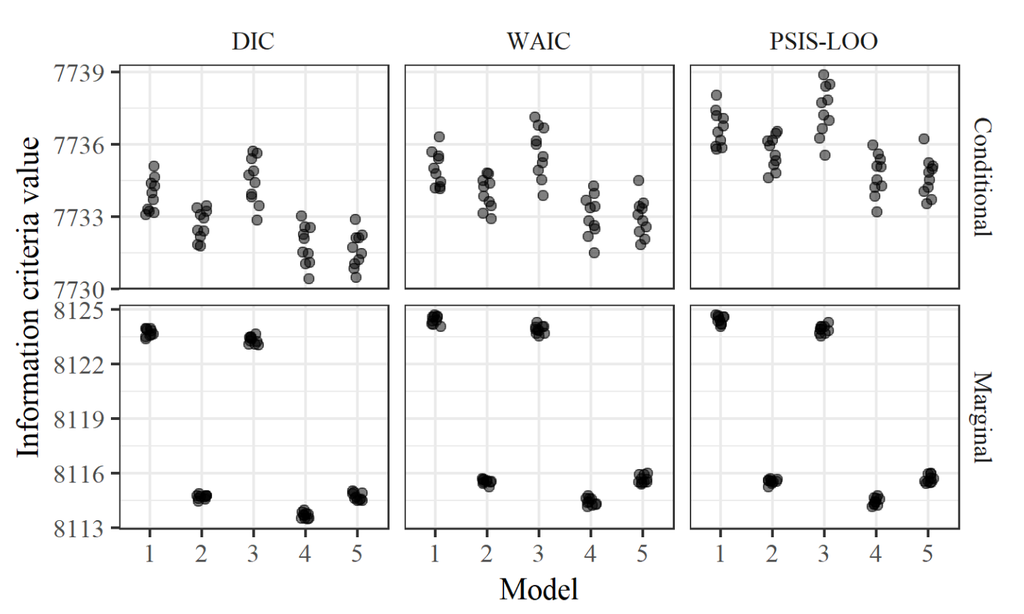

## Number of effective parameters

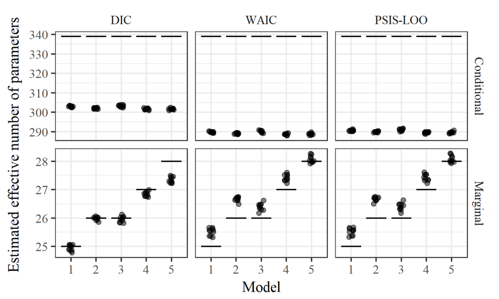